# Analysing differential localisation experiments with BANDLE

Oliver M. Crook

18 August 2021

#### Abstract

This vignette describes how to analyse a mass-spectrometry based differential localisation experiments using BANDLE. Data should be stored as lists of `MSnSet`s. There is also features for quality control and visualisation of results. Other vignettes are for convergence and other methodology

#### Package

bandle 1.0

# 1 A well-defined differential localisation experiment

We are going to generate a differential localisation experiment. They key elements are replicates, and a perturbation of interest. There is code within the `bandle` package to simulate an example experiment. First we will use the `pRolocdata` package to obtain a spatial proteomics dataset. This will be the basis of our simulation which will use boostrapping to generate new datasets.

```r
library("pRolocdata")
data("tan2009r1")
```

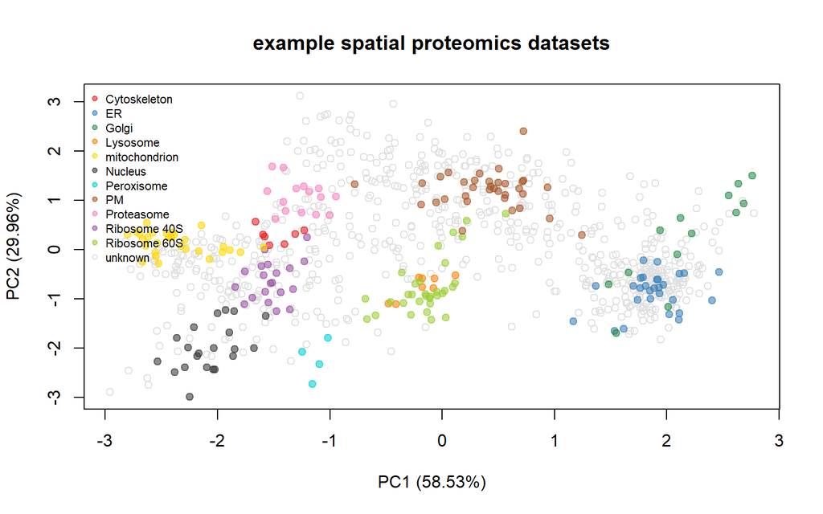

```r
plot2D(tan2009r1,
       main = "example spatial proteomics datasets", grid = FALSE)
addLegend(tan2009r1, where = "topleft", cex = 0.7)
```

The following code chuck simulates a differential localisation experiment. It will generate `numRep/2` of each a control and treatment condition. We will also simulate relocalisations for `numDyn` proteins.

```r
set.seed(1)
tansim <- sim_dynamic(object = tan2009r1,
                      numRep = 6,
                      numDyn = 100)
```

[figure not shown]

For understanding, exploring and visualizing individual spatial proteomics experiments, see the vignettes in `pRoloc` and `MSnbase` packages.

```r
tansim$lopitrep[[1]]
```

```
## MSnSet (storageMode: lockedEnvironment)
## assayData: 888 features, 4 samples
##   element names: exprs
## protocolData: none
## phenoData
##   sampleNames: X114 X115 X116 X117
##   varLabels: Fractions
##   varMetadata: labelDescription
## featureData
##   featureNames: P20353 P53501 ... P07909 (888 total)
##   fvarLabels: FBgn Protein.ID ... knn.scores (18 total)
##   fvarMetadata: labelDescription
## experimentData: use 'experimentData(object)'
##   pubMedIds: 19317464
## Annotation:
## - - - Processing information - - -
## Added markers from  'mrk' marker vector. Thu Jul 16 22:53:44 2015
## Performed knn prediction (k=10) Wed Aug 18 15:07:13 2021
##  MSnbase version: 1.17.12
```

# 2 Preparing for BANDLE analysis

The main function of the bandle package is `bandle`, this uses a complex model to analyse the data. Markov-Chain Monte-Carlo (MCMC) is used to sample the posterior distribution of parameters and latent variables. From which statistics of interest can be computed. Here we only run a few iterations for brevity but typically one needs to run thousands of iterations to ensure convergence, as well as multiple parallel chains.

First, we need to fit non-parametric regression functions to the markers profiles, upon which we place our analysis. This uses Gaussian processes. The fitting uses some default penalised complexity priors, which work well. However, these can be altered, which is demonstrated in the next code chunk

```r
par(mfrow = c(3,4))
gpParams <- lapply(tansim$lopitrep, function(x) fitGPmaternPC(x))
```

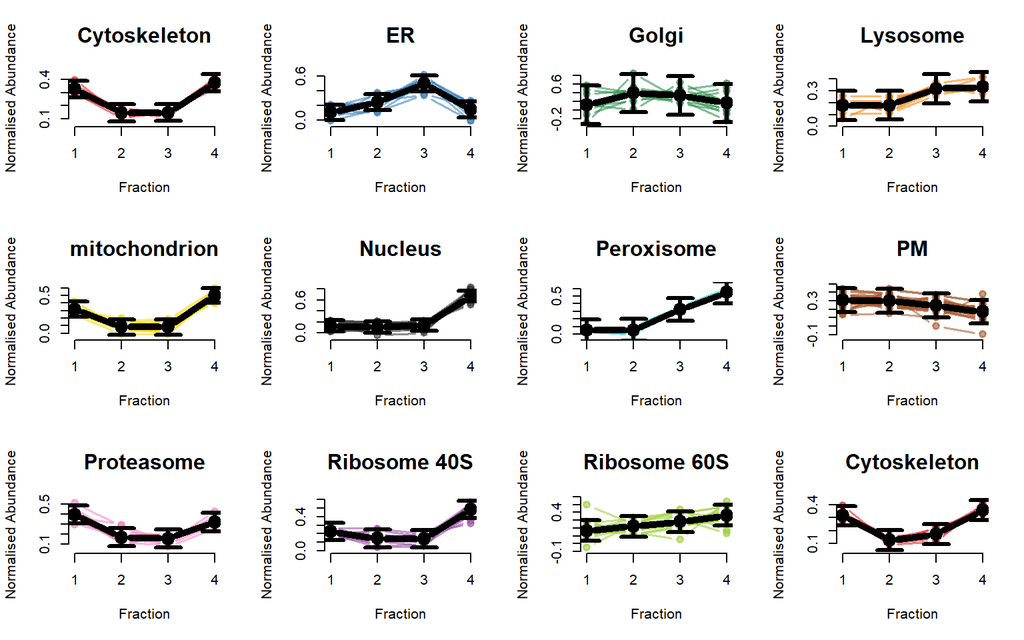

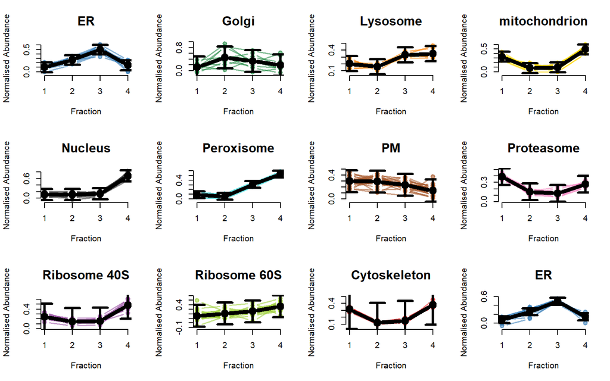

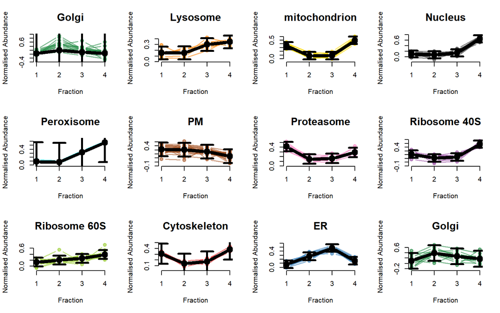

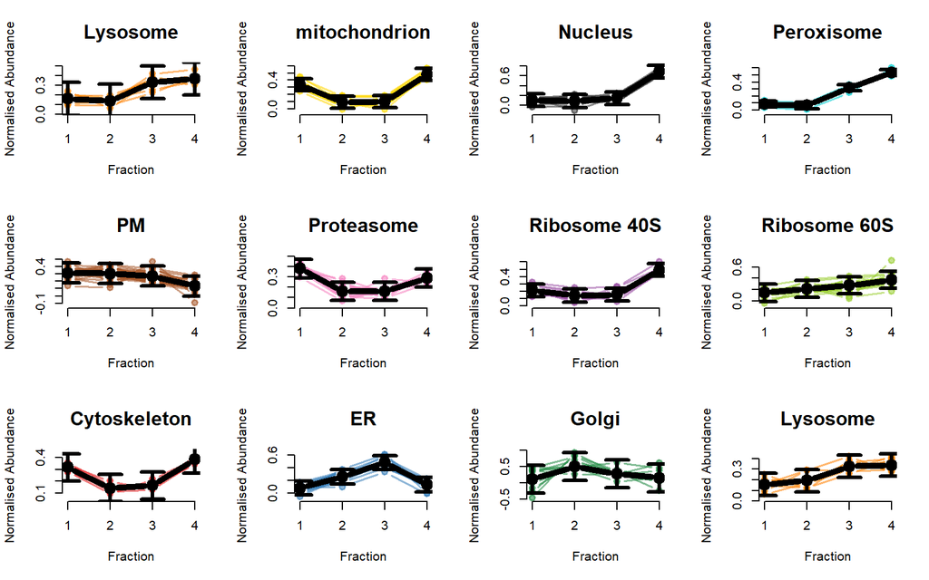

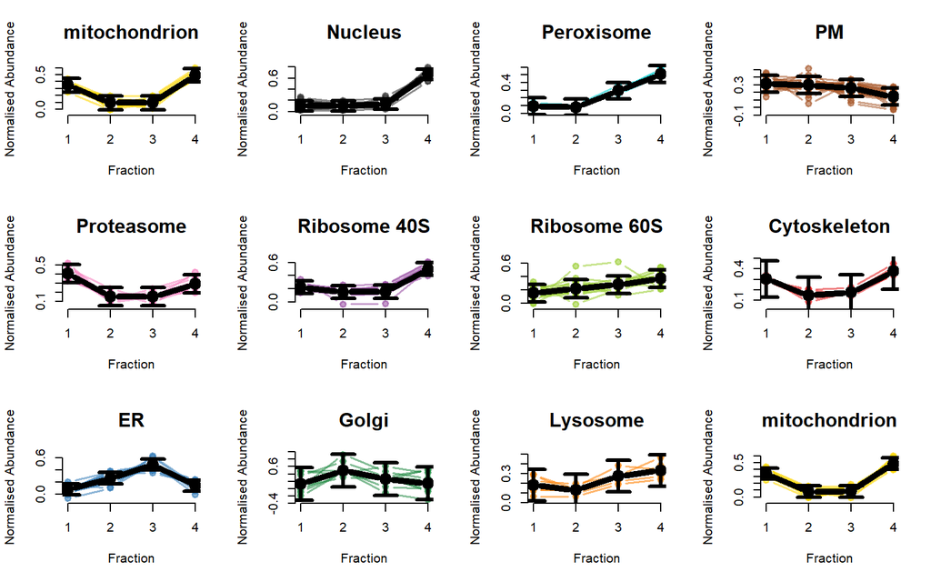

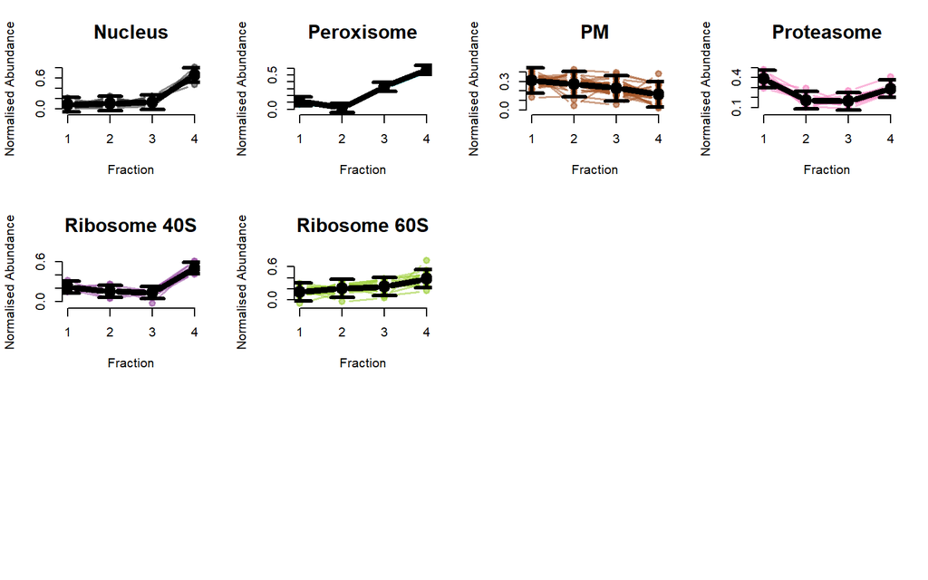

The prior needs to form a `K*3` matrix, which gives the prior the length-scale amplitude and standard deviation parameters. Increasing these values, increases the shrinkage. For more details see the bandle paper.

```r
K <- length(getMarkerClasses(tansim$lopitrep[[1]]))
pc_prior <- matrix(NA, ncol = 3, K)
pc_prior[seq.int(1:K), ] <- matrix(rep(c(10, 60, 250),
                                       each = K), ncol = 3)
```

```r
par(mfrow = c(3,4))
gpParams <- lapply(tansim$lopitrep,
                   function(x) fitGPmaternPC(x, hyppar = pc_prior))
```

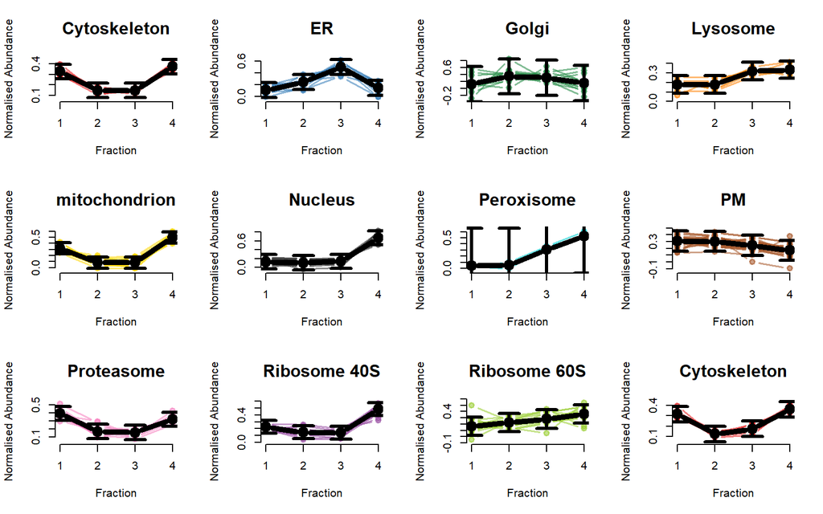

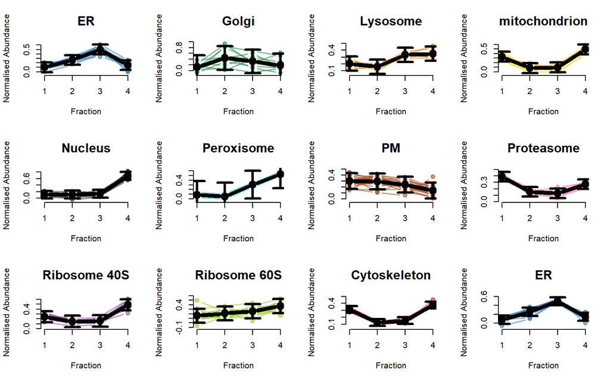

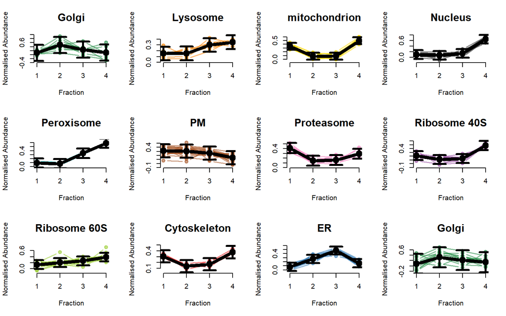

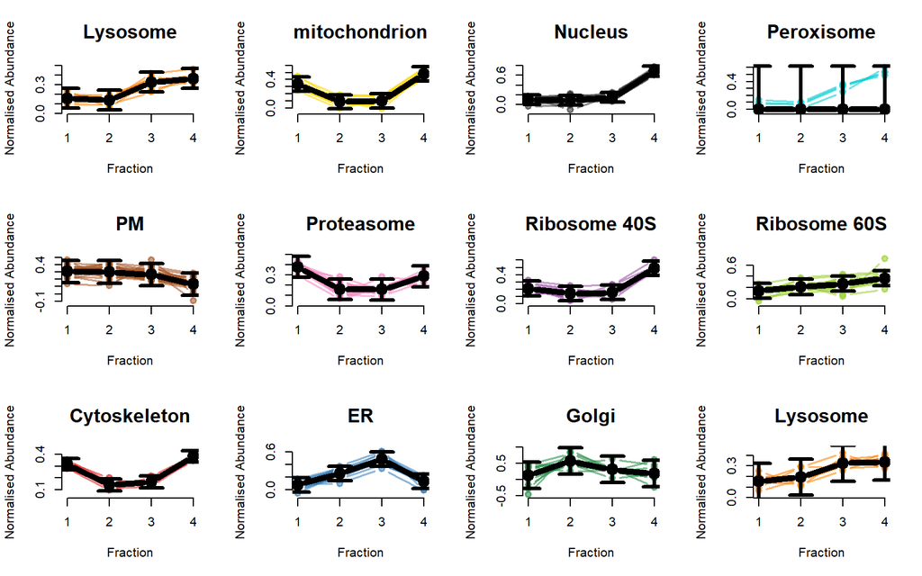

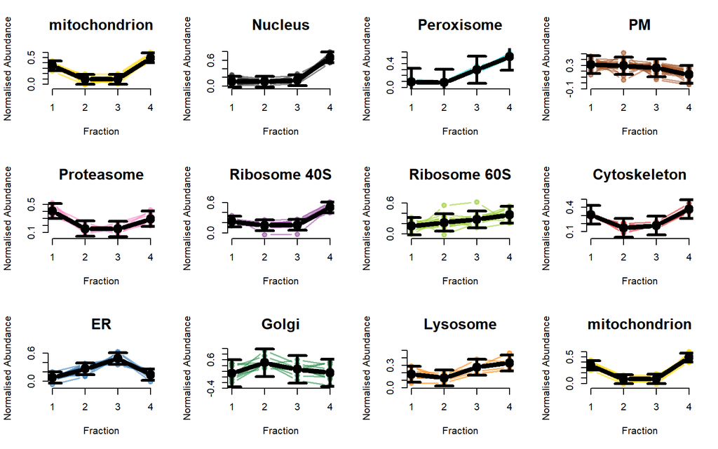

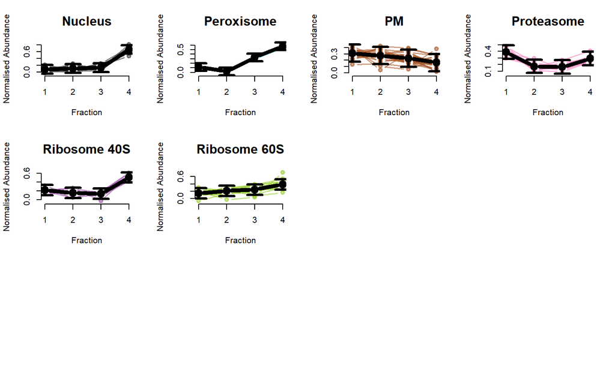

# 3 Setting the prior on the weights

The next step is to set up the matrix Dirichlet prior on the mixing weights. These weights are defined across datasets so these are slightly different to mixture weights in usual mixture models. The $(i,j)^{th}$ entry is the prior probability that a protein localises to organelle $i$ in the control and $j$ in the treatment. This mean that off-diagonal terms have a different interpretation to diagonal terms. Since we expect relocalisation to be rare, off-diagonal terms should be small. The following functions help set up the priors and how to interpret them. The parameter `q` allow us to check the prior probability that more than `q` differential localisations are expected.

```r
dirPrior = diag(rep(1, K)) + matrix(0.001, nrow = K, ncol = K)
predDirPrior <- prior_pred_dir(object = tansim$lopitrep[[1]],
                               dirPrior = dirPrior,
                               q = 15)
```

The mean number of relocalisation is small:

```r
predDirPrior$meannotAlloc
```

```
## [1] 0.3535431
```

The prior probability that more than `q` differential localisations are expected is small

```r
predDirPrior$tailnotAlloc
```

```
## [1] 6e-04
```

The full prior predictive can be visualised as histogram. The prior probability that proteins are allocated to different components between datasets concentrates around 0.

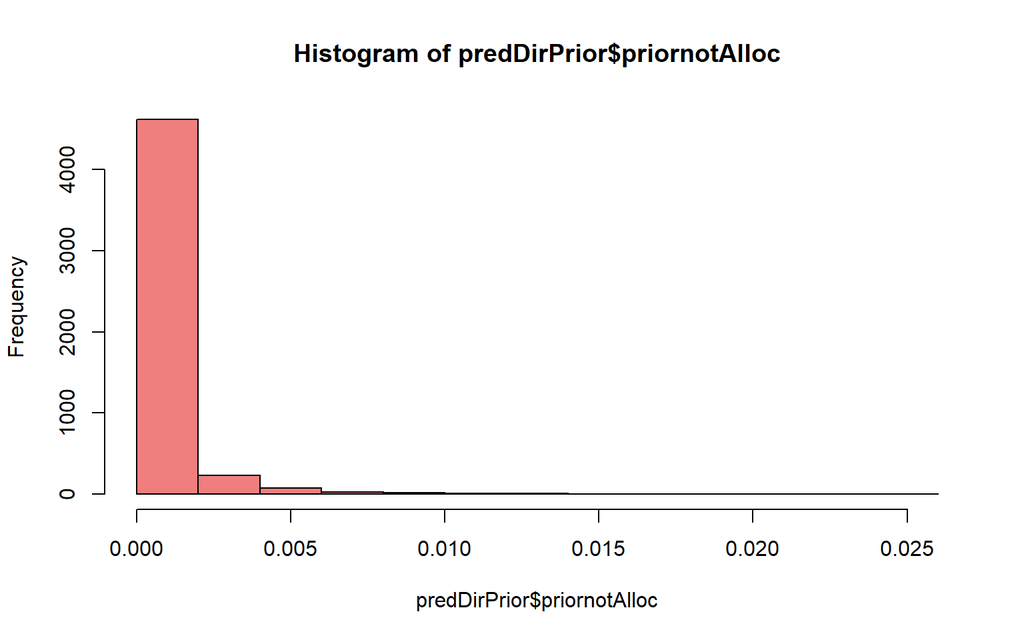

```r
hist(predDirPrior$priornotAlloc, col = getStockcol()[1])
```

# 4 The bandle function

We are now ready to run the main bandle function. Remember to carefully select the datasets and replicates that define the control and treatment. Furthermore, iterations are typically $1000$s, a few are run here for the convenience of the vignette.

```r
control <- tansim$lopitrep[1:3]
treatment <- tansim$lopitrep[4:6]
bandleres <- bandle(objectCond1 = control,
                    objectCond2 = treatment,
                    numIter = 50, # usually 10,000
                    burnin = 5, # usually 5,000
                    thin = 1, # usually 20
                    gpParams = gpParams,
                    pcPrior = pc_prior,
                    numChains = 1, # usually >=4
                    dirPrior = dirPrior)
```

The bandle function generates an object of class `bandleParams`. The `show` method indicates the number of parallel chains that were run, this should typically be greater than 4.

```r
bandleres
```

```
## Object of class "bandleParams"
## Method: bandle
## Number of chains: 1
```

# 5 The summary slot

Currently, the summary slots of the `bandleres` object are empty. The `summaries` function accesses them.

```r
summaries(bandleres)
```

```
## [[1]]
## An object of class "bandleSummary"
## Slot "posteriorEstimates":
## DataFrame with 0 rows and 0 columns
##
## Slot "diagnostics":
## <0 x 0 matrix>
##
## Slot "bandle.joint":
## <0 x 0 matrix>
##
##
## [[2]]
## An object of class "bandleSummary"
## Slot "posteriorEstimates":
## DataFrame with 0 rows and 0 columns
##
## Slot "diagnostics":
## <0 x 0 matrix>
##
## Slot "bandle.joint":
## <0 x 0 matrix>
```

These can be populated as follows

```r
bandleres <- bandleProcess(bandleres)
```

These slot have now been populated

```r
summary(summaries(bandleres))
```

```
##      Length Class         Mode
## [1,] 1      bandleSummary S4
## [2,] 1      bandleSummary S4
```

The `posteriorEstimates` slot gives posterior quantities of interest for different proteins. The object is of length 2, 1 for control and 1 for treatment.

```r
length(summaries(bandleres))
```

```
## [1] 2
```

One quantity of interest is the protein allocations, which we can plot in a barplot

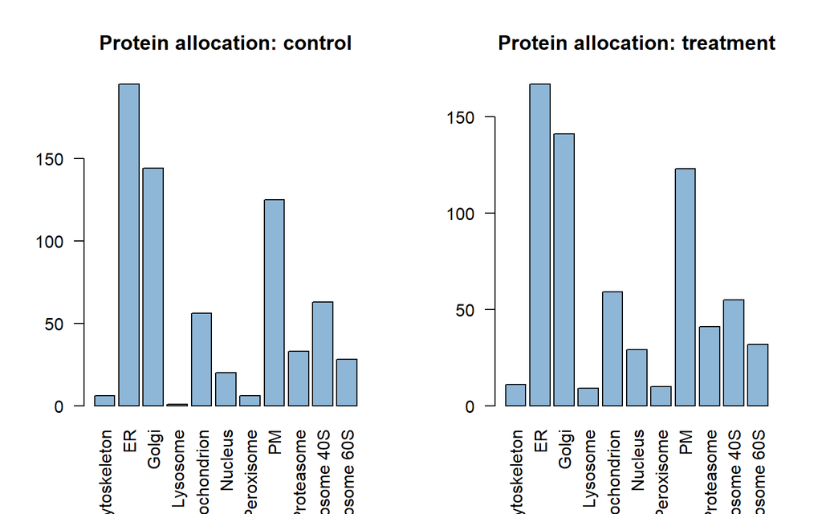

```r
par(mfrow = c(1, 2))

pe1 <- summaries(bandleres)[[1]]@posteriorEstimates
barplot(table(pe1$bandle.allocation), col = getStockcol()[2], las = 2, main = "Protein allocation: control")

pe2 <- summaries(bandleres)[[2]]@posteriorEstimates
barplot(table(pe2$bandle.allocation), col = getStockcol()[2], las = 2, main = "Protein allocation: treatment")
```

# 6 Differential localisation probability

The differential localization probability is also stored here, which gives the proteins that are most likely to differentially localised. The rank plot is a good visualisation. Indicating that most proteins are not differentially localised and there are a few confident differentially localised protiens.

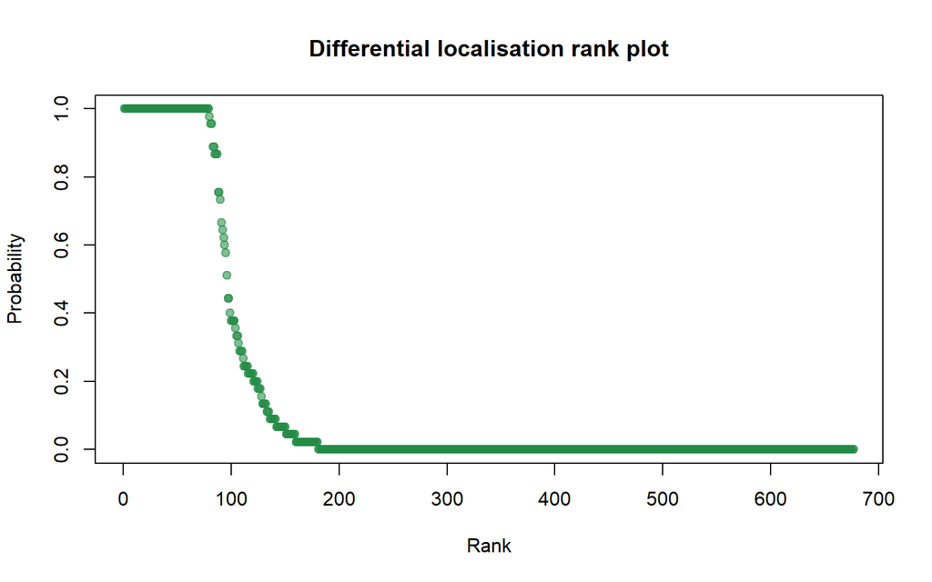

```r
diffloc_probs <- pe1$bandle.differential.localisation
plot(diffloc_probs[order(diffloc_probs, decreasing = TRUE)],
     col = getStockcol()[3], pch = 19, ylab = "Probability",
     xlab = "Rank", main = "Differential localisation rank plot")
```

We can examine the top `n` proteins (here 100) and produce bootstrap estimates of the uncertainty (note here the uncertainty is likely to be underestimated as we did not produce many mcmc samples). These can be visualised as ranked boxplots

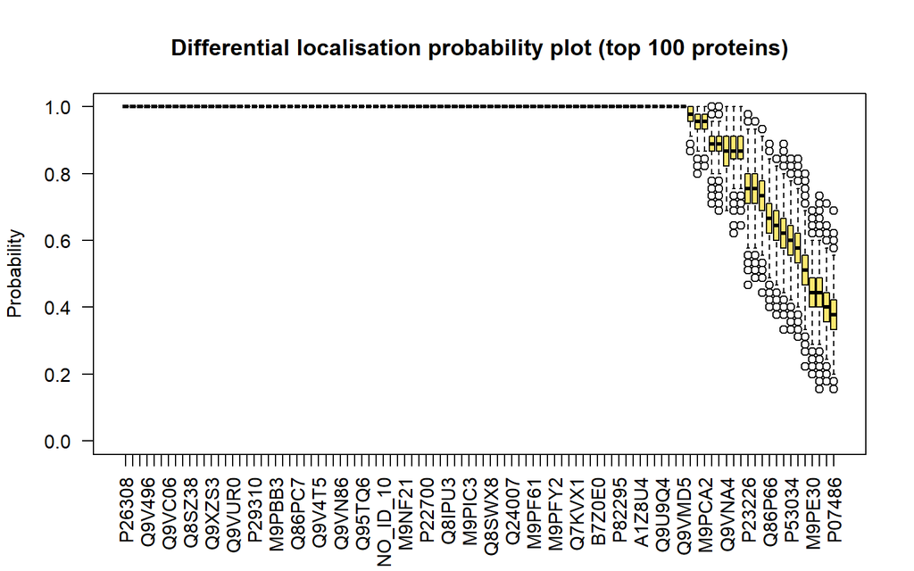

```r
set.seed(1)
bt <- bootstrapdiffLocprob(params = bandleres, top = 100)
boxplot(t(bt), col = getStockcol()[5],
        las = 2, ylab = "Probability", ylim = c(0, 1),
        main = "Differential localisation probability plot (top 100 proteins)")
```

Let see how many proteins in the top 100 match those we had simulated relocalisations for.

```r
sum(tansim$perm1_names %in% rownames(bt))
```

```
## [1] 82
```

```r
sum(!(tansim$perm1_names %in% rownames(bt)))
```

```
## [1] 18
```

# 7 Visualising translocations

We can visualise the changes in localisation between conditions on an alluvial plot using the `plotTranslocations` function

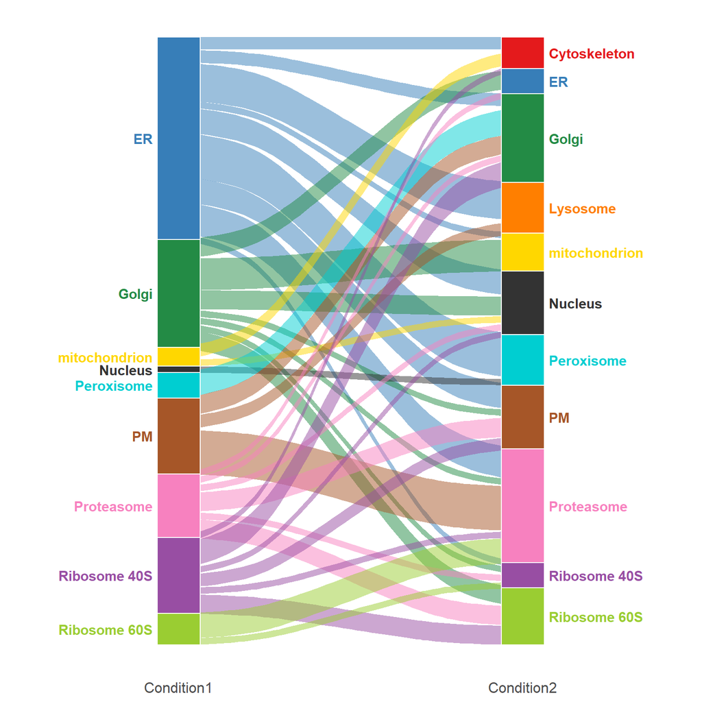

```r
plotTranslocations(bandleres)
```

Or alternatively, on a chord (circos) diagram

```r
plotTranslocations(bandleres, type = "chord")
```

[output not shown]

# 8 Allocation probabilities

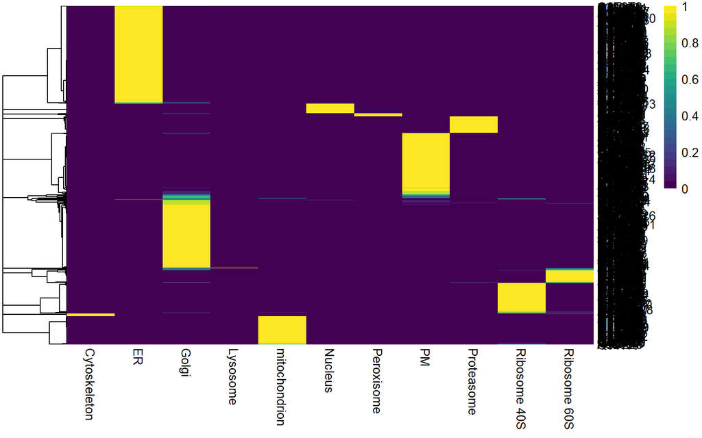

```r
bjoint_control <- summaries(bandleres)[[1]]@bandle.joint
pheatmap(bjoint_control, cluster_cols = FALSE, color = viridis(n = 25))
```

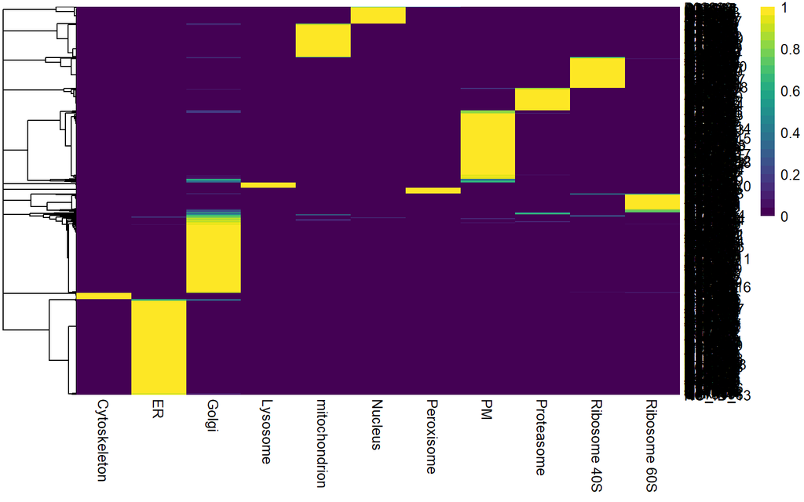

```r
bjoint_treatment <- summaries(bandleres)[[2]]@bandle.joint
pheatmap(bjoint_treatment, cluster_cols = FALSE, color = viridis(n = 25))
```

# 9 Session information